# Aprendizaje, Generalización y Sobreajuste

Validación cruzada

Grupo de Meteorología

# 1 Elementos del Aprendizaje: Modelo de aprendizaje

Para que un problema sea adecuado para su resolución mediante técnicas de aprendizaje automático, debe cumplir inicialmente tres condiciones:

- Debe existir un patrón, el cual queremos aprender a través de las técnicas de aprendizaje adecuadas.
- No debe existir solución analítica a nuestro problema o, de existir, debe ser complicada de obtener por medios analíticos.
- Debe existir una base de datos suficiente para poder inferir el patrón de ellos.

De las tres condiciones anteriores, realmente la fundamental es la existencia de datos para alimentar el algoritmo de aprendizaje ya que, en ausencia de las otras dos condiciones las técnicas podrían aplicarse igualmente a pesar de que tuviese más o menos sentido hacerlo.

Partiendo de la definición de aprendizaje introducida -procedimiento (automático) por el cual se construye/ajusta un modelo particular (de la familia de modelos posibles) a partir de un conjunto de datos de entrenamiento que se considera representativo de la distribución que se quiere modelar-, nuestro modelo de aprendizaje viene dado por el **algoritmo usado** para aprender el patrón y la familia de **funciones** y **datos** que utilicemos para aproximar el patrón a aprender. De este modo, el proceso de aprendizaje dependerá de estos tres elementos, los cuales establecerán nuestras limitaciones e incertidumbres a la hora tanto de aprender el patrón como de realizar predicciones con el patrón aprendido.

# 2 Generalización y sobreajuste

Recordemos que el objetivo principal del modelo aprendido es que tenga **la capacidad de generalizar**, es decir, la capacidad de funcionar bien para nuevos datos que no forman parte de la muestra de entrenamiento (por ejemplo, una muestra de datos de test). En caso contario, diremos que el modelo está **sobreajustado a la muestra de entrenamiento**. Un ejemplo viene dado por la aproximación de una función que pase por `N` puntos. A nivel teórico, dados `N` puntos existe un polinomio de grado `N-1` el cual pasa por los `N` puntos. Por lo tanto, dicho polinomio `P(x)` tendrá error 0 para la muestra dada. Sin embargo, si consideramos otra muestra independiente la probabilidad de que dicha muestra quede ajustada por el polinomio obtenido es 0 ya que sólo existe un caso (que la función que quiero ajustar sea P(x)) favorable de todos los polinomios de grado `N-1` que puedo construir (infinitos). Por lo tanto, aún habiendo obtenido una solución con error 0 para el conjunto de entrenamiento, dicha solución carece de capacidad de generalización.

**La introducción de grados de libertad en la familia de funciones consideradas en el aprendizaje suele dar lugar a modelos sobreajustados**, por lo que suele ser conveniente partir de los modelos más simples e ir introduciendo grados de libertad progresivamente si fuera necesario.

Teniendo en cuenta que sólo podemos evaluar el error de nuestro modelo aprendido en la muestra de entrenamiento, **¿cómo analizar el sobreajuste del modelo?**

Mediante **técnicas de validación cruzada y técnicas de remuestreo o bootstraping**

La validación cruzada se basa en separar la muestra en dos conjuntos disjuntos, uno de entrenamiento y otro de test, que permita analizar tanto el error muestral como la capacidad de generalización de nuestro modelo aprendido en la fase de entrenamiento a través del conjunto de test.

En esta práctica utilizaremos…

- modelo: Regresion lineal
- Dataset: Auto (paquete ISLR)
- Validación: error medio absoluto (MAE) y error cuadrático medio (MSE)
- Librerías de R:

```r
library(ISLR)
library(caret)
```

# 3 Carga y transformación de datos

El dataset Auto (paquete ISLR) contiene información sobre las características de 392 vehículos.

```r
data(Auto)
str(Auto)
```

```r
?Auto
# Conversion de libras a Kg
Auto$weight <- Auto$weight * 0.453592
```

Comenzamos con un análisis preliminar de nuestros datos:

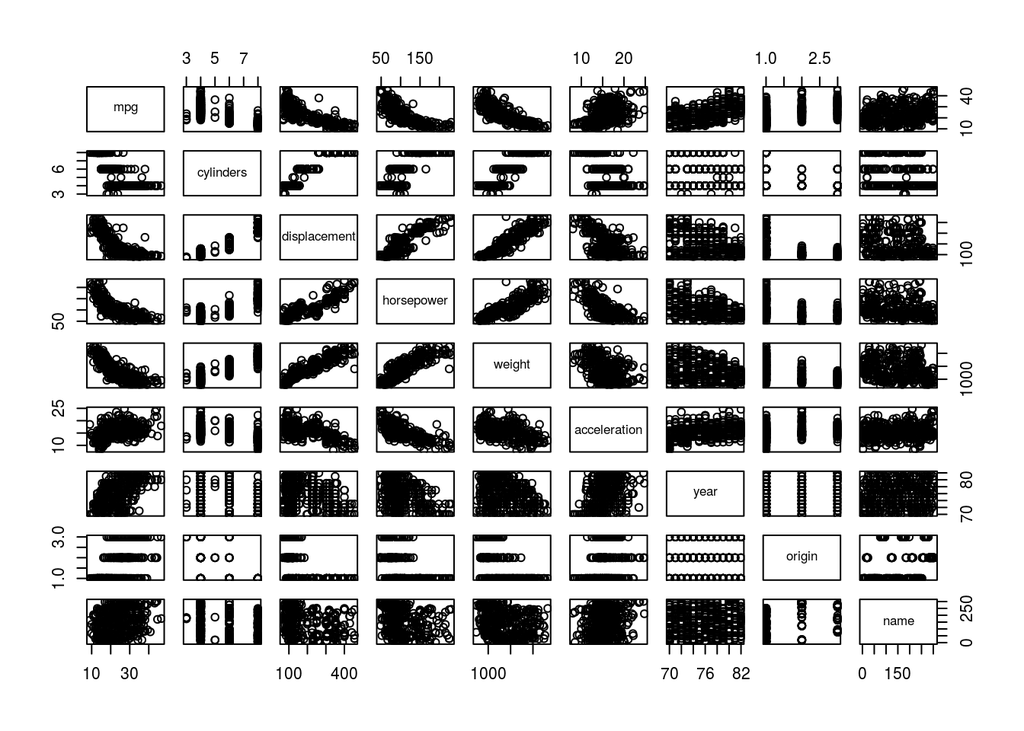

```r
pairs(Auto)
```

En este ejemplo solo nos interesa la relación entre el peso (weight) y la potencia (horsepower).

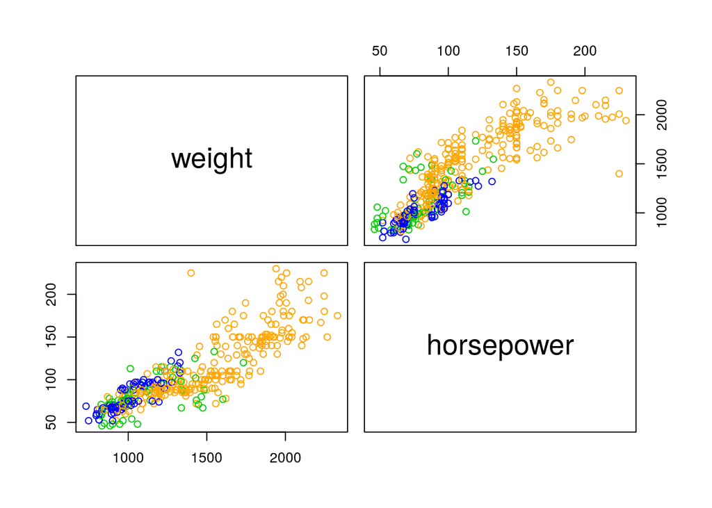

```r
pairs(weight ~ horsepower, data = Auto, col = c("orange", "green3", "blue")[unclass(Auto$origin)])
```

Imaginemos que una empresa X nos proporciona únicamente los registros o datos europeos para que obtengamos un modelo capaz de estimar los pesos de los coches americanos en función de la potencia.

```r
Auto$origin <- as.character(
                  factor(Auto$origin,
                         labels = c("American", "Japanese", "European")))
# muestra de test
america <- Auto[Auto$origin == "American", ]
# muestra de train
europe <- Auto[Auto$origin == "European", ]
```

Visualicemos ambos conjuntos:

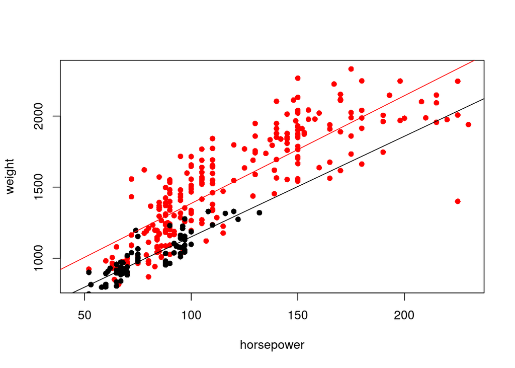

```r
plot(america$horsepower, america$weight,
     xlab = "horsepower", ylab = "weight",
     pch = 16, col = "red",
     xlim = range(Auto$horsepower))
points(europe$horsepower, europe$weight, pch = 16)
# La función `lm` realiza el ajuste de un modelo lineal entre ambas variables:
abline(lm(weight~horsepower, data = america), col = "red")
abline(lm(weight~horsepower, data = europe))
```

# 4 Definición de las funciones de error

Este modo de definir funciones es bastante útil en R.

```r
# Functions
mae <- function(obs, est) {
  mean(abs(obs - est))
}

rmse <- function(obs, est) {
  sqrt(mean((obs - est)^2))
}
```

# 5 Modelización y evaluación

La función `lm` realiza el ajuste de un modelo lineal entre ambas variables:

```r
# Salida de la regresion
reg <- lm(weight~horsepower, data = europe)
summary(reg)
```

Podemos extraer los “fitted values” de `reg`, es decir, el resultado de la applicación del modelo ajustado a los propios datos de entrenamiento `yest`, para comparar la estimación (o predicción) del modelo con los datos reales (observados).

```r
yest <- reg$fitted.values
```

—Nota: Lo que obtenemos en la linea anterior es lo mismo que utilizar nuestro modelo para predecir el weight en base a la horsepower que se utilizo en el proceso de entrenamiento:

```r
yest <- predict(object = reg, newdata = data.frame(horsepower = europe$horsepower))
```

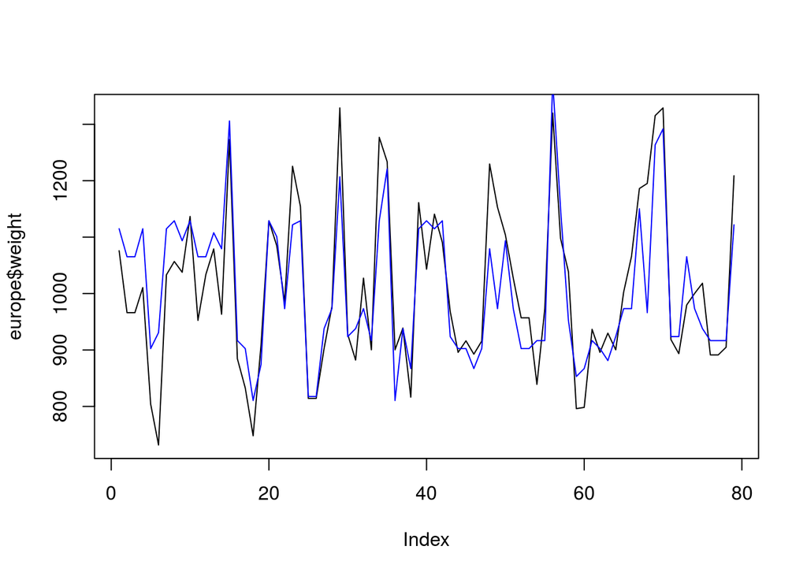

```r
plot(europe$weight, type = 'l')
lines(yest, col = 'blue')
```

Por último calculamos el MAE y el MSE:

```r
mae(obs = europe$weight, yest)
```

```
## [1] 55.00146
```

```r
rmse(obs = europe$weight, yest)
```

```
## [1] 71.83323
```

```r
cor(europe$weight, yest, method = "spearman")
```

```
## [1] 0.8813537
```

El ejercicio anterior utiliza todos los datos para entrenar y validar el modelo. Es decir, la validación se realiza utilizando como conjunto de validación el mismo conjunto utilizado como “train” (conjunto de entrenamiento). Por lo tanto no podemos estimar la capacidad de generalización o sobreajuste del modelo.

Si la validación se realiza sobre un conjunto independiente de la muestra de entrenamiento el error esperable es mayor.

## 5.1 Modelización y validación hold out

El modo más básico de analizar el error de mi modelo es dividiendo la muestra en subconjuntos disjuntos (hold out). En este primer caso consideraremos sólo dos conjuntos, uno de train y otro de validación con la mitad de datos (instancias, i.e. filas) en cada uno.

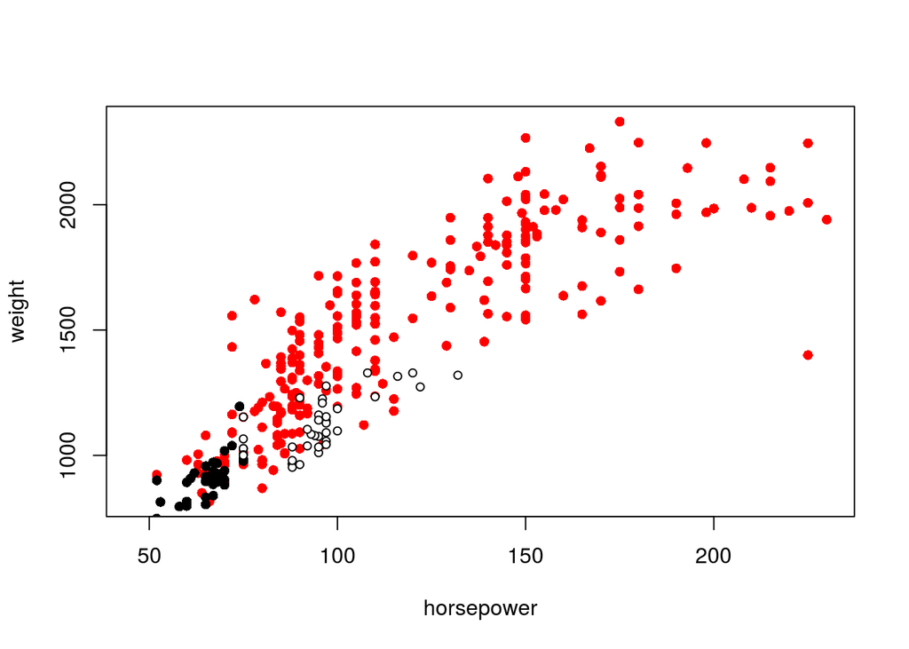

```r
n <- nrow(europe)
ind <- order(europe$horsepower)[1:ceiling(n/2)]
europe.train <- europe[ind, ]
europe.val <- europe[-ind,]

plot(america$horsepower, america$weight,
     xlab = "horsepower", ylab = "weight",
     pch = 16, col = "red",
     xlim = range(Auto$horsepower))
points(europe.train$horsepower, europe.train$weight, pch = 16, col = "black")
points(europe.val$horsepower, europe.val$weight, pch = 21, bg = "white", cex = 0.8)
```

Aplicamos de nuevo la funciones `lm` (para ajustar el modelo) y `predict` (para aplicar el modelo sobre los datos de “train” y de “validación”) y calculamos el RMSE:

```r
reg0 <- lm(weight~horsepower, data = europe.train)
yest0.train <- predict(reg0, newdata = data.frame(horsepower = europe.train$horsepower))
yest0.val <- predict(reg0, newdata = data.frame(horsepower = europe.val$horsepower))
rmse(europe.train$weight, yest0.train)
```

```
## [1] 65.29786
```

```r
rmse(europe.val$weight, yest0.val)
```

```
## [1] 92.58811
```

Hemos entrenado con los valores de horsepower menores, por lo que **nuestra muestra no es representativa de la población**.

### 5.1.1 Muestreo aleatiorio para obtener las muestras de train y de validación

Para intentar minimizar el sesgo de nuestra muestra de entrenamiento, una solución es aleatorizar la selección. En este ejemplo utilizamos la función `sample` para obtener un índice de registros aleatoria.

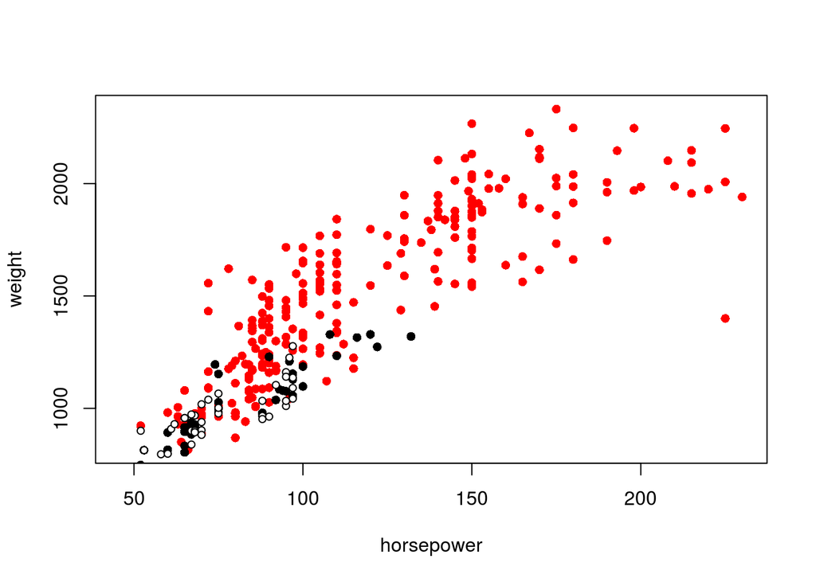

```r
n <- nrow(europe)
set.seed(1)
ind <- sample(1:n, ceiling(n/2))
europe.train <- europe[ind, ]
europe.val <- europe[-ind,]

plot(america$horsepower, america$weight,
     xlab = "horsepower", ylab = "weight",
     pch = 16, col = "red",
     xlim = range(Auto$horsepower))
points(europe.train$horsepower, europe.train$weight, pch = 16, col = "black")
points(europe.val$horsepower, europe.val$weight, pch = 21, bg = "white", cex = 0.8)
```

Aplicamos de nuevo la funciones `lm` (para ajustar el modelo) y `predict` (para aplicar el modelo sobre los datos de “train” y de “validación”) y calculamos el RMSE:

```r
reg1 <- lm(weight~horsepower, data = europe.train)
yest1.train <- predict(reg1, newdata = data.frame(horsepower = europe.train$horsepower))
yest1.val <- predict(reg1, newdata = data.frame(horsepower = europe.val$horsepower))
rmse(europe.train$weight, yest1.train)
```

```
## [1] 68.84407
```

```r
rmse(europe.val$weight, yest1.val)
```

```
## [1] 75.66424
```

Al considerar una muestra representativa de la variabilidad de la población el error de validación es más bajo y se asemeja más al error de train que en el ejemplo anterior.

**El modelo entrenado con una muestra aleatoria de `europe` tiene más capacidad de generalización**

Decimos que existe sobreajuste cuando el error de train y el de validación son muy diferentes. Un modelo con capacidad de generalización, no sobreajustado, es aquel para el que ambos errores, en la muestra de entrenamiento y de test, son similares/comparables.

A pesar de ello, esta metodología tiene dos inconvenientes potenciales:

- 1.- La estimación del error en el conjunto de test puede variar mucho en función de la partición considerada.

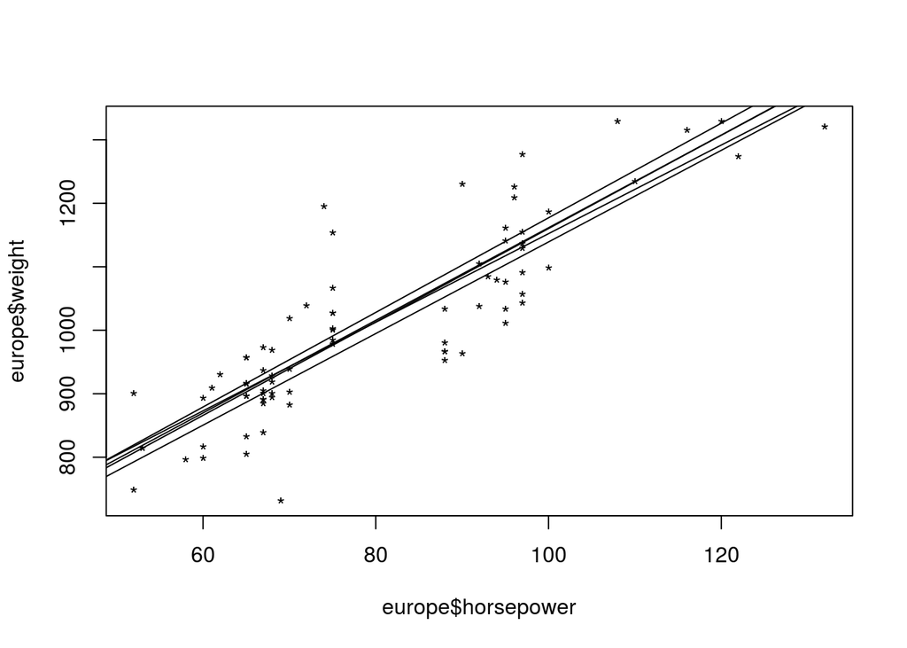

```
## [1] 81.20835
## [1] 74.58629
## [1] 72.36649
## [1] 76.71821
## [1] 74.55969
```

```r
plot(europe$horsepower, europe$weight, pch = "*")
for (i in c(1:5)) {
  ind <- sample(1:n, ceiling(n/2))
  europe.train.i <- europe[ind, ]
  europe.val.i <- europe[-ind, ]
  reg.i <- lm(weight~horsepower, data = europe.train.i)
  yest.val.i <- predict(reg.i, data.frame(horsepower = europe.val.i$horsepower))
  abline(reg.i)
  print(rmse(europe.val.i$weight, yest.val.i))
}
```

- 2.- El error de validación puede ser sobreestimado. Dado que el modelo se entrena en un subconjunto de la muestra y que los métodos estadísticos suelen comportarse peor cuando son entrenados con pocos datos (n/2 = 40 en los ejemplos anteriores), esto puede dar lugar a una sobrestimación del error de validación respecto al obtenido considerando toda la muestra.

La validación cruzada (cross-validación) que aplicaremos un poco más adelante considera estos dos problemas.

## 5.2 Modelización y cross-validación leave-one-out

Como alternativa al muestreo aleatorio existe el método de validación cruzada denominado leave-one-out:

- La selección de la muestra de entrenamiento NO se hace aleatoriamente, eliminando la variabilidad del error de validación.
- La muestra de entrenamiento es la mayor posible que considera una muestra de validación.
- Si un conjunto de datos tiene `N` registros, el ajuste del modelo se realiza con `N - 1` registros y el registro no considerado en el conjunto de entrenamiento se utiliza como validación o muestra independiente para validar el modelo.
- Esta operación se repite `N` veces, así todos los registros del dataset se utilizan como dato de test para un modelo entrenado con el resto de registros.

```r
ind <- 1:n
yest.2 <- numeric(length = length(ind))

for (i in ind) {
  Reg.i <- lm(weight~horsepower, data = europe, subset = ind[-i])
  yest.2[i] <- predict(Reg.i, data.frame(horsepower = europe$horsepower[i]))
}
rmse(europe$weight, yest.2)
```

```
## [1] 73.4328
```

### 5.2.1 ejemplo anterior con la librería caret

```r
ctrl <- trainControl(method = "LOOCV")
mod <- train(weight ~ horsepower,
               data = europe,
               method = "lm",
               trControl = ctrl)
mod
```

```
## Linear Regression
##
## 79 samples
##  1 predictors
##
## No pre-processing
## Resampling: Leave-One-Out Cross-Validation
## Summary of sample sizes: 78, 78, 78, 78, 78, 78, ...
## Resampling results:
##
##   RMSE     Rsquared  MAE
##   73.4328  0.741626  56.36828
##
## Tuning parameter 'intercept' was held constant at a value of TRUE
```

```r
mod$results$RMSE
```

```
## [1] 73.4328
```

## 5.3 Modelización y cross-validación k-fold

Si el tamaño muestral es grande el método leave-one-out es computacionalmente costoso. Para evitar este coste surge otro método de validación cruzada: **El método k-fold** en el que se hace un leave-one-out por “bloques” o “folds”:

- se divide la muestra en `k` subconjuntos.
- Se ajustan `k` modelos, considerando en cada caso un bloque como conjunto de validación y los `k-1` restantes como muestra de entrenamiento.
- La estimación dependerá de como se realice la partición de los datos. La variabilidad mayor que en el caso del leave-one-out.
- Con un número suficiente de subconjuntos, se obtienen los mismos resultados y conclusiones que las obtenidas con un leave-one-out.

Consideramos el ejemplo anterior con 10 subconjuntos y vamos paso a paso.

1. Dividimos la muestra en 10 subconjuntos (`k = 10`)

```r
k <- 10
# Número de registros (instancias u observaciones) en nuestro dataset.
n <- nrow(europe)
# factor de números aleatorios con k levels (del 1 al 10)
set.seed(1)
split.factor <- sample(rep(1:10, each = ceiling(n/k)), n)
# Lista que en cada "slot" contiene un fold
spl.europe <- split(europe, f = split.factor)
str(spl.europe)
```

```
## List of 10
##  $ 1 :'data.frame':  8 obs. of  9 variables:
##   ..$ mpg         : num [1:8] 23 24 32 44.6 33.8 32.7 37 32.4
##   ..$ cylinders   : num [1:8] 4 4 4 4 4 6 4 4
##   ..$ displacement: num [1:8] 120 119 85 91 97 168 85 108
##   ..$ horsepower  : num [1:8] 97 97 70 67 67 132 65 75
##   ..$ weight      : num [1:8] 1137 1154 903 839 973 ...
##   ..$ acceleration: num [1:8] 14.5 17 17 13.8 18 11.4 19.4 16.8
##   ..$ year        : num [1:8] 72 75 76 80 80 80 81 81
##   ..$ origin      : chr [1:8] "European" "European" "European" "European" ...
##   ..$ name        : Factor w/ 304 levels "amc ambassador brougham",..: 279 88 91 170 262 81 80 266
##  $ 2 :'data.frame':  8 obs. of  9 variables:
##   ..$ mpg         : num [1:8] 31 27 20 22 32.4 33.7 31.6 34
##   ..$ cylinders   : num [1:8] 4 4 4 6 4 4 4 4
##   ..$ displacement: num [1:8] 71 97 97 146 107 107 120 108
##   ..$ horsepower  : num [1:8] 65 88 88 97 72 75 74 70
##   ..$ weight      : num [1:8] 804 953 1034 1277 1039 ...
##   ..$ acceleration: num [1:8] 19 16.5 19 14.5 17 14.4 18.3 16.9
##   ..$ year        : num [1:8] 71 72 73 77 80 81 81 82
##   ..$ origin      : chr [1:8] "European" "European" "European" "European" ...
##   ..$ name        : Factor w/ 304 levels "amc ambassador brougham",..: 267 268 263 89 164 172 175 266
##  $ 3 :'data.frame':  8 obs. of  9 variables:
##   ..$ mpg         : num [1:8] 24 32 28 31.5 27.2 31.8 32.3 38
##   ..$ cylinders   : num [1:8] 4 4 4 4 4 4 4 4
##   ..$ displacement: num [1:8] 113 83 97 98 119 85 97 91
##   ..$ horsepower  : num [1:8] 95 61 75 68 97 65 67 67
##   ..$ weight      : num [1:8] 1076 909 977 928 1043 ...
##   ..$ acceleration: num [1:8] 15 19 16.4 18.5 14.7 19.2 17.8 16.2
##   ..$ year        : num [1:8] 70 74 76 77 78 79 81 82
##   ..$ origin      : chr [1:8] "European" "European" "European" "European" ...
##   ..$ name        : Factor w/ 304 levels "amc ambassador brougham",..: 274 88 266 165 84 79 261 83
##  $ 4 :'data.frame':  8 obs. of  9 variables:
##   ..$ mpg         : num [1:8] 27 18 33.5 32.8 38.1 32.9 31 36
##   ..$ cylinders   : num [1:8] 4 3 4 4 4 4 4 4
##   ..$ displacement: num [1:8] 97 70 85 78 89 119 91 120
##   ..$ horsepower  : num [1:8] 88 90 70 52 60 100 68 88
##   ..$ weight      : num [1:8] 966 963 882 900 893 ...
##   ..$ acceleration: num [1:8] 14.5 13.5 16.8 19.4 18.8 14.8 17.6 14.5
##   ..$ year        : num [1:8] 70 73 77 78 80 81 82 82
##   ..$ origin      : chr [1:8] "European" "European" "European" "European" ...
```

[output cut: 46 more lines]

```
##   ..$ weight      : num [1:8] 1011 732 833 985 816 ...
##   ..$ acceleration: num [1:8] 14 18 21 16 16.4 14.8 14.9 14.5
##   ..$ year        : num [1:8] 71 71 74 75 78 78 78 82
##   ..$ origin      : chr [1:8] "European" "European" "European" "European" ...
##   ..$ name        : Factor w/ 304 levels "amc ambassador brougham",..: 271 76 267 266 171 265 77 164
##  $ 10:'data.frame':  8 obs. of  9 variables:
##   ..$ mpg         : num [1:8] 24 33 33 26 27.5 29.5 29.8 35.1
##   ..$ cylinders   : num [1:8] 4 4 4 4 4 4 4 4
##   ..$ displacement: num [1:8] 113 91 91 97 134 98 134 81
##   ..$ horsepower  : num [1:8] 95 53 53 75 95 68 90 60
##   ..$ weight      : num [1:8] 1033 814 814 1027 1161 ...
##   ..$ acceleration: num [1:8] 15.5 17.5 17.4 18.2 14.2 16.6 15.5 16.1
##   ..$ year        : num [1:8] 72 75 76 77 78 78 80 81
##   ..$ origin      : chr [1:8] "European" "European" "European" "European" ...
##   ..$ name        : Factor w/ 304 levels "amc ambassador brougham",..: 272 171 167 269 271 166 273 169
```

2. ajustamos el modelo con la función `lm` con `k-1` y predecimos (función `predict`) sobre el fold restante. Se repite la operación `k` veces (en un bucle lapply):

```r
yest.3 <- lapply(1:k, function(x) {
  reg.3 <- lm(weight~horsepower, data = do.call("rbind", spl.europe[-x]))
  predict(reg.3, data.frame(horsepower = spl.europe[[x]]$horsepower))
})
str(yest.3)
```

```
## List of 10
##  $ : Named num [1:8] 1131 1131 937 915 915 ...
##   ..- attr(*, "names")= chr [1:8] "1" "2" "3" "4" ...
##  $ : Named num [1:8] 898 1061 1061 1124 947 ...
##   ..- attr(*, "names")= chr [1:8] "1" "2" "3" "4" ...
##  $ : Named num [1:8] 1118 873 973 923 1132 ...
##   ..- attr(*, "names")= chr [1:8] "1" "2" "3" "4" ...
##  $ : Named num [1:8] 1070 1085 939 809 867 ...
##   ..- attr(*, "names")= chr [1:8] "1" "2" "3" "4" ...
##  $ : Named num [1:7] 917 1119 1217 938 882 ...
##   ..- attr(*, "names")= chr [1:7] "1" "2" "3" "4" ...
##  $ : Named num [1:8] 1066 1094 1108 1129 1291 ...
##   ..- attr(*, "names")= chr [1:8] "1" "2" "3" "4" ...
##  $ : Named num [1:8] 1130 1309 900 900 1094 ...
##   ..- attr(*, "names")= chr [1:8] "1" "2" "3" "4" ...
##  $ : Named num [1:8] 813 1096 1200 917 972 ...
##   ..- attr(*, "names")= chr [1:8] "1" "2" "3" "4" ...
##  $ : Named num [1:8] 1119 937 910 979 875 ...
##   ..- attr(*, "names")= chr [1:8] "1" "2" "3" "4" ...
##  $ : Named num [1:8] 1112 818 818 972 1112 ...
##   ..- attr(*, "names")= chr [1:8] "1" "2" "3" "4" ...
```

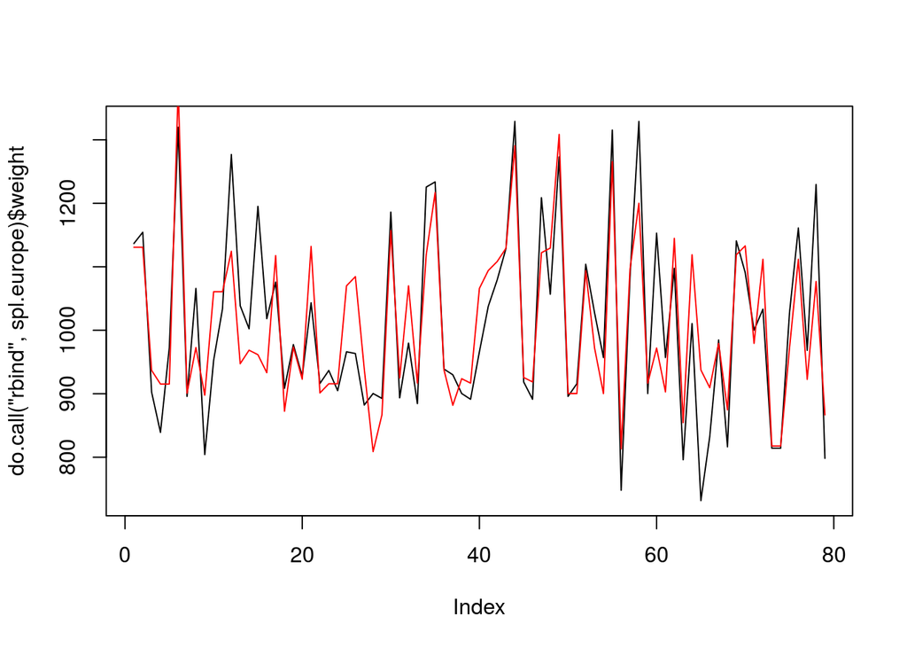

```r
# Hacemos un plot de los valores de weight rales frente a los estimados
plot(do.call("rbind", spl.europe)$weight, typ = "l")
lines(do.call("c", yest.3), col = "red")
```

3. Calculamos el error

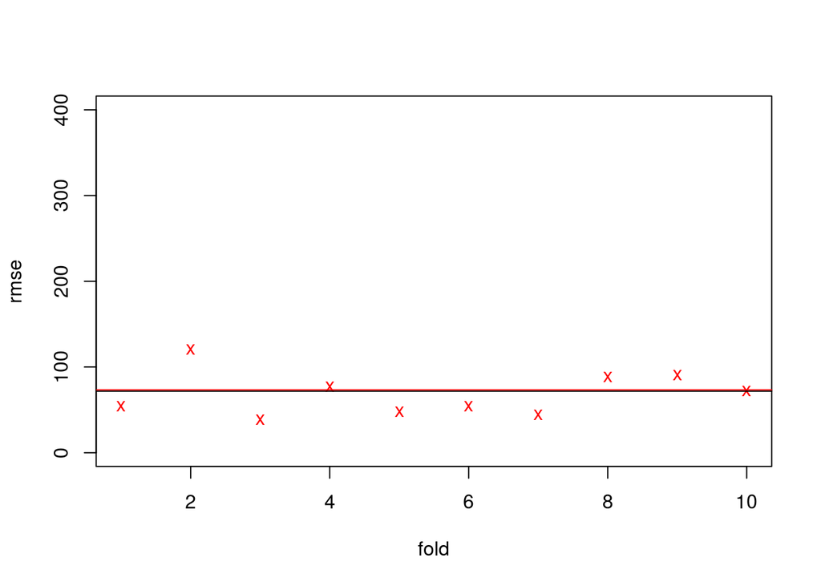

```r
# de cada fold
rmse.val.3.folds <- lapply(1:length(spl.europe), function(x) rmse(spl.europe[[x]]$weight, yest.3[[x]]))
# de la muestra entera
rmse.val.3 <- rmse(do.call("rbind", spl.europe)$weight, do.call("c", yest.3))
plot(do.call("c", rmse.val.3.folds), ylab = "rmse", xlab = "fold", pch = "x", ylim = c(0, 400), col = "red")
abline(h = rmse.val.3, col = "red")
abline(h = rmse(obs = europe$weight, yest))
```

# 6 Práctica 1

¿Es el modelo aprendido con los registros europeos adecuado para estimar el peso de los coches americanos? (¿qué ocurre cuando aplicamos el modelo a la muestra de test (objeto `america`)?)

Utiliza las funciones de visualización (`plot`, `points`, `lines`, `abline`, …) para ilustrar los resultados.

Escribe el código a continuación:

[figure not shown]

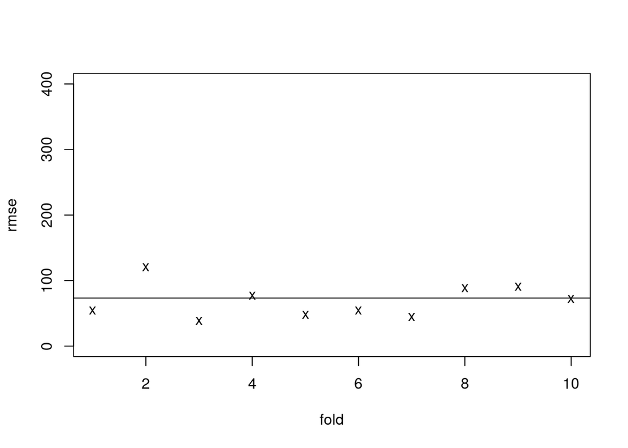

```r
reg.3.all <- lm(weight~horsepower, data = europe)

#(...)

plot(do.call("c", rmse.val.3.folds), ylab = "rmse", xlab = "fold", pch = "x", ylim = c(0, 400))
abline(h = rmse.val.3)
```

```r
#abline(...

#(...)
```

# 7 Práctica 2

Utiliza la librería caret para reproducir el último ejemplo de cross-validación con k-fold y obten el error de validación global.

Escribe el código a continuación:

# 8 Práctica 3

Utiliza los datos de los coches americanos para estimar los pesos de los coches europeos por un lado y la de los japoneses por otro.

¿Es el modelo aprendido adecuado para estimar el peso de los coches europeos y japoneses?

Utiliza caret y las funciones de visualización (`plot`, `points`, `lines`, `abline`, …) para ilustrar los resultados.

Escribe el código a continuación:

```
## Linear Regression
##
## 245 samples
##   1 predictors
##
## No pre-processing
## Resampling: Cross-Validated (10 fold)
## Summary of sample sizes: 219, 220, 221, 221, 221, 221, ...
## Resampling results:
##
##   RMSE      Rsquared   MAE
##   194.4469  0.7343611  162.0253
##
## Tuning parameter 'intercept' was held constant at a value of TRUE
```

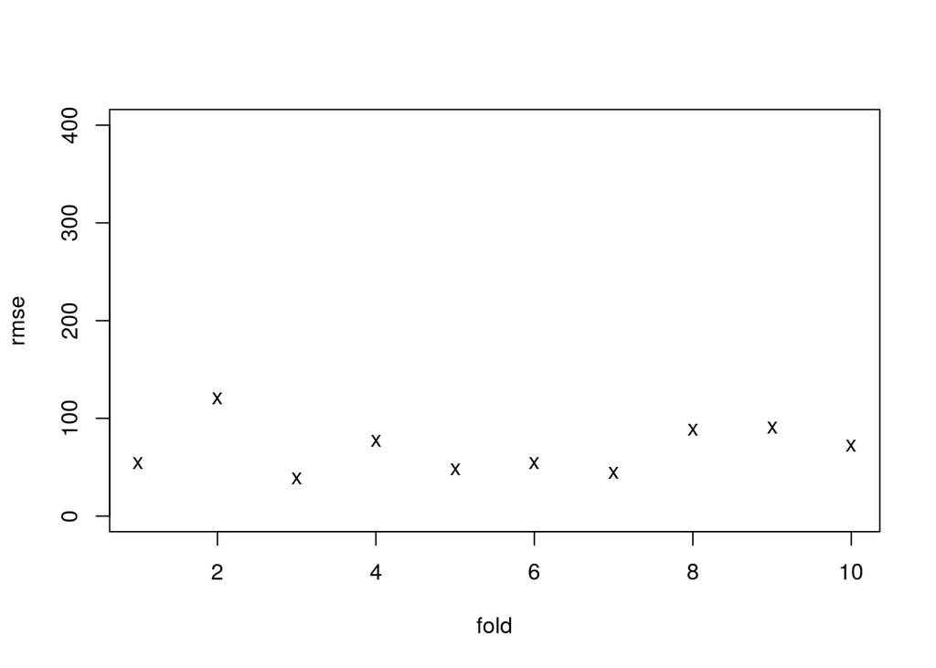

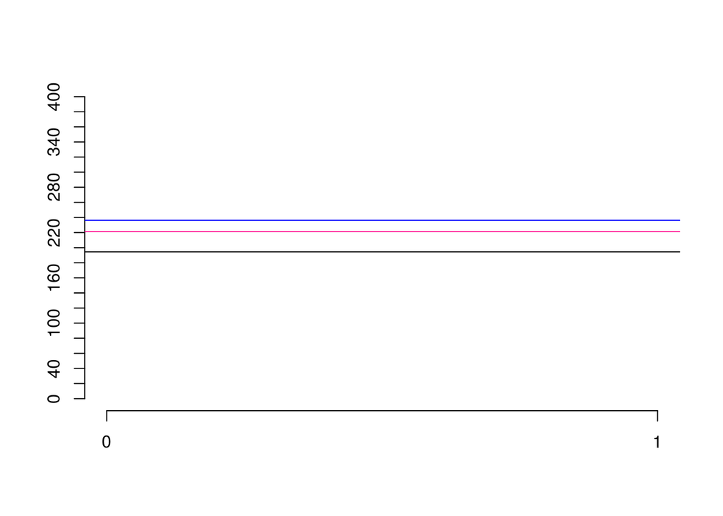

# 9 Práctica 4